# Gender Wage Gap in STEM Occupations

December 1, 2024

## Step 1 - Attach Necessary Libraries

```r
library(tidyverse)
library(openxlsx)
library(readxl)
library(rio)
library(lmerTest)
```

## Step 2 - Clean and Combine Data

```r
# Taking Table 2 from each Excel file and adding them to a new Excel file
# Each Table 2 is a separate sheet in this singular file
wb <- createWorkbook()
file_list <- list.files(path = "~/Documents/GitHub Portfolio/STEM Wage Gap Project/Spreadsheets", full.names = TRUE)

for (file in file_list) {
  table2_data <- read.xlsx(file, sheet = 'Table 2')
  sheet_name <- tools::file_path_sans_ext(basename(file))
  addWorksheet(wb, sheetName = sheet_name)
  writeData(wb, sheet = sheet_name, x = table2_data)
}

saveWorkbook(wb, file = 'Table2_Only.xlsx', overwrite = TRUE)

# Now combining each Table 2 into one big table
path <- "~/Documents/GitHub Portfolio/STEM Wage Gap Project/Table2_Only.xlsx"
combined_data <- import_list(path, rbind = TRUE)
colnames(combined_data)[12] <- 'File'
write.xlsx(combined_data, file = 'combined_Table2.xlsx', overwrite = TRUE)

cleaned_data <- read.xlsx("~/Documents/GitHub Portfolio/STEM Wage Gap Project/cleaned_data.xlsx")

years <- c('2015', '2016', '2017', '2018', '2019', '2020', '2021', '2022', '2023')
cleaned_data <- cleaned_data %>%
  mutate(Year = years[File])

cleaned_data <- cleaned_data %>%
  mutate(Difference = 100 - Percentage)
```

## Step 3 - Explore General Wage Gap

### Heatmap

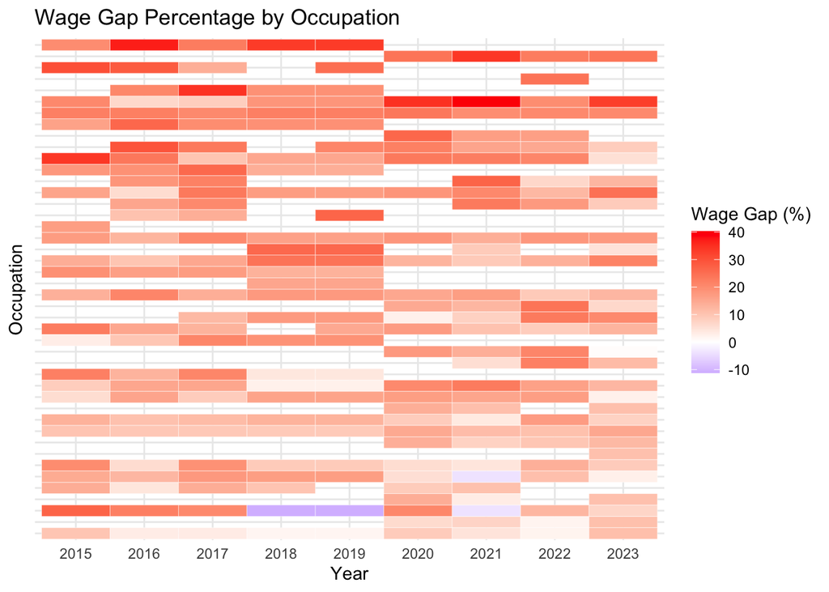

```r
ggplot(cleaned_data, aes(x = Year, y = reorder(Occupation, Difference), fill = Difference)) +
  geom_tile(color = 'white') +
  scale_fill_gradient2(low = 'blue', mid = "white", high = 'red', midpoint = 0,
                       name = "Wage Gap (%)") +
  labs(title = "Wage Gap Percentage by Occupation",
       x = 'Year',
       y = 'Occupation') +
  theme_minimal() +
  theme(axis.text.y = element_blank())
```

As seen in the heatmap, there are four data points where women earned more than men. Three of those were associated with the occupation of clinical laboratory technologists and technicians in 2018, 2019, and 2021. The fourth data point is for pharmacists in 2021. From the data used, this is only 1.57% of occupations over nine years where women earned more than men. Of this percentage, the actual salary gap only ranged from 3.8-11.2%. So while there might be a few instances where women had a higher salary than men, the difference in earnings was relatively low. Furthermore, the darkest red tiles are associated with the occupations with the largest wage gap. These are physicians and surgeons, medical scientists, financial analysts, and engineering technologists. It is of note that these are some of the highest paid jobs within the dataset.

### Linear Mixed-Effects Model

```r
data_filtered <- cleaned_data %>%
  group_by(Occupation) %>%
  filter(n_distinct(Year) > 1) %>%
  ungroup()

model <- lmer(Difference ~ Year + (1 | Occupation), data = data_filtered)
summary(model)
```

```
## Linear mixed model fit by REML. t-tests use Satterthwaite's method [
## lmerModLmerTest]
## Formula: Difference ~ Year + (1 | Occupation)
##    Data: data_filtered
##
## REML criterion at convergence: 1690.7
##
## Scaled residuals:
##     Min      1Q  Median      3Q     Max
## -3.2707 -0.5376  0.0364  0.4779  3.1556
##
## Random effects:
##  Groups     Name        Variance Std.Dev.
##  Occupation (Intercept) 17.50    4.183
##  Residual               44.85    6.697
## Number of obs: 252, groups:  Occupation, 41
##
## Fixed effects:
##             Estimate Std. Error       df t value Pr(>|t|)
## (Intercept)  17.4500     1.5529 218.8193  11.237   <2e-16 ***
## Year2016     -1.7043     1.8600 206.8469  -0.916   0.3606
## Year2017     -0.5051     1.8474 207.0701  -0.273   0.7848
## Year2018     -2.6934     1.9124 208.2338  -1.408   0.1605
## Year2019     -1.9343     1.8655 208.3979  -1.037   0.3010
## Year2020     -0.7556     1.9313 217.5297  -0.391   0.6960
## Year2021     -3.5284     1.8783 218.9021  -1.879   0.0616 .
## Year2022     -2.1151     1.9351 217.8776  -1.093   0.2756
## Year2023     -4.5683     1.9075 218.9183  -2.395   0.0175 *
## ---
## Signif. codes:  0 '***' 0.001 '**' 0.01 '*' 0.05 '.' 0.1 ' ' 1
##
## Correlation of Fixed Effects:
##          (Intr) Yr2016 Yr2017 Yr2018 Yr2019 Yr2020 Yr2021 Yr2022
## Year2016 -0.662
## Year2017 -0.668  0.557
## Year2018 -0.643  0.530  0.535
## Year2019 -0.663  0.548  0.553  0.536
## Year2020 -0.662  0.527  0.533  0.513  0.527
## Year2021 -0.687  0.546  0.552  0.530  0.544  0.568
## Year2022 -0.663  0.530  0.536  0.512  0.528  0.548  0.568
## Year2023 -0.676  0.538  0.544  0.522  0.538  0.558  0.580  0.560
```

The data suggested a slight decrease in the wage gap from 2015 to 2023. In order to test this observation, I created a Linear Mixed-Effects Model to model the wage gap as a function of time. By doing so, I tested the significance in the fluctuations in wage gap over time in order to determine if there has been any change. This resulted in all p-values from 2016 to 2022 to be greater than 0.05. This means the difference in wage gap was not statistically significant. However, in 2023, the p-value was 0.0175, which is less than 0.05. This means the 4% decrease in the wage gap was statistically significant. However, considering the majority of the model’s results were statistically insignificant, there is not enough evidence to claim an increase or decrease in the wage gap for STEM occupations over the last nine years.

## Step 4 - High vs Low Earning Occupations

### Highest Earning STEM Occupations

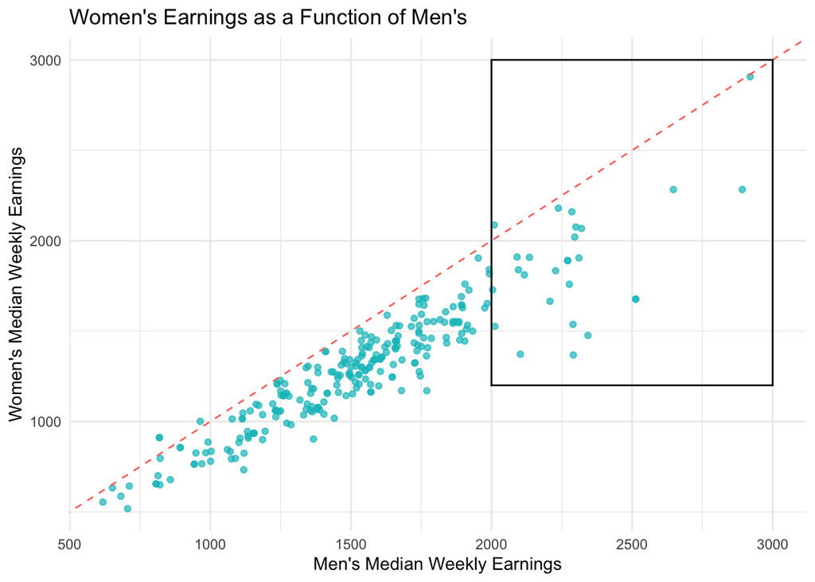

```r
above_equality <- cleaned_data[cleaned_data$W.Median.weekly.earnings > cleaned_data$M.Median.weekly.earnings, ]

ggplot(cleaned_data, aes(x = M.Median.weekly.earnings, y = W.Median.weekly.earnings)) +
  geom_point(color = '#00BFC4', alpha = 0.7) +
  geom_abline(slope = 1, intercept = 0, linetype = 'dashed', color = '#F8766D') +
  annotate("rect",
           xmin = 2000, xmax = 3000,
           ymin = 1200, ymax = 3000,
           color = "black", fill = NA, linewidth = 0.5, linetype = "solid") +
  theme_minimal() +
  labs(
    title = "Women's Earnings as a Function of Men's",
    x = "Men's Median Weekly Earnings",
    y = "Women's Median Weekly Earnings"
  )
```

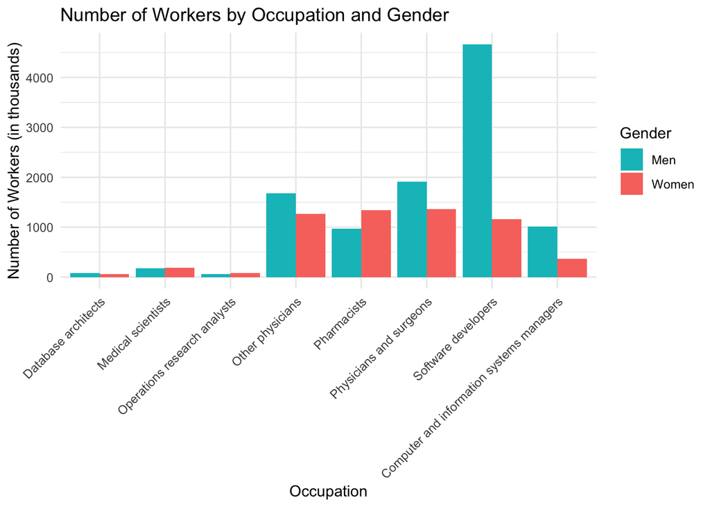

```r
highest <- cleaned_data[cleaned_data$M.Median.weekly.earnings > 2000, ]

highest_num_workers <- highest %>%
  group_by(Occupation) %>%
  summarise(
    W.total.workers = sum(W.Num.Workers),
    M.total.workers = sum(M.Num.Workers),
    total.num.workers = sum(Total.Num.Workers)
  )

high_order <- c('Database administrators and architects', 'Medical scientists', 'Operations research analysts', 'Other physicians', 'Pharmacists', 'Physicians and surgeons', 'Software developers', 'Computer and information systems managers')

high_abbrev <- c('Database architects', 'Medical scientists', 'Operations research analysts', 'Other physicians', 'Pharmacists', 'Physicians and surgeons', 'Software developers', 'Computer and information systems managers')
highest_num_workers$Occupation <- factor(highest_num_workers$Occupation, levels = high_order, labels = high_abbrev)

highest_combined <- pivot_longer(
  highest_num_workers,
  cols = c('W.total.workers', 'M.total.workers'),
  names_to = 'Gender',
  values_to = 'Num.Workers'
  )

ggplot(highest_combined, aes(x = Occupation, y = Num.Workers, fill = Gender)) +
  geom_bar(stat = 'identity', position = 'dodge') +
  theme_minimal() +
  theme(axis.text.x = element_text(angle = 45, hjust = 1)) +
  labs(
    title = "Number of Workers by Occupation and Gender",
    y = "Number of Workers (in thousands)"
  ) +
  scale_fill_discrete(
    labels = c('Men', 'Women'),
    type = c('#00BFC4', '#F8766D')
  )
```

The first plot highlights the eight highest earning occupations, where men earned more than $2000 weekly. The second plot represents the average number of workers for these occupations over the last nine years. As seen in the scatter plot, the highest paying jobs are associated with some of the largest wage gaps. Physicians and surgeons are the highest paid and have the largest gap. The average wage gap for these eight occupations is $454.64 weekly, which is 20.13%. In addition, 64.46% of workers in these occupations are male. This indicates a trend of more men working in these higher paid occupations and also earning a higher salary than the women.

### Lowest Earning STEM Occupations

This can be compared to the below scatter plot, which highlights the seven lowest earnings occupations, where men earned less than $1000 weekly. Additionally, the below bar chart represents the average number of workers for these occupations over the last nine years. As seen in the scatter plot, some of the smallest wage gaps are associated with these lower paying jobs. When paired with bar chart, it is evident that more women than men currently hold these positions. The average wage gap for these seven occupations is $96.00 weekly, which is 11.22%. This is about a 9% difference in wage gaps between the lowest and highest paying jobs. Furthermore, 65.22% of workers in these occupations are female. This indicates a trend of more women working in lower paid positions, however still being paid less than men. Although it is of note that the gap is less severe for these jobs, it is still present.

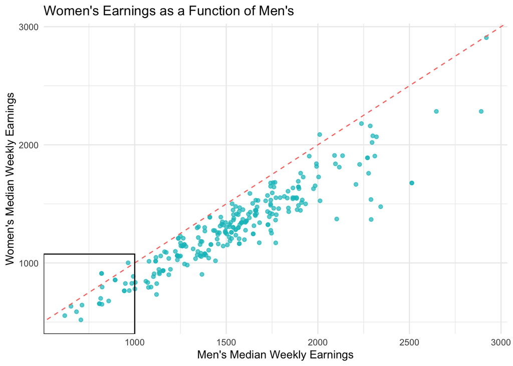

```r
ggplot(cleaned_data, aes(x = M.Median.weekly.earnings, y = W.Median.weekly.earnings)) +
  geom_point(color = '#00BFC4', alpha = 0.7) +
  geom_abline(slope = 1, intercept = 0, linetype = 'dashed', color = '#F8766D') +
  annotate("rect",
           xmin = -Inf, xmax = 1000,
           ymin = -Inf, ymax = 1075,
           color = "black", fill = NA, linewidth = 0.5, linetype = "solid") +
  theme_minimal() +
  labs(
    title = "Women's Earnings as a Function of Men's",
    x = "Men's Median Weekly Earnings",
    y = "Women's Median Weekly Earnings"
  )
```

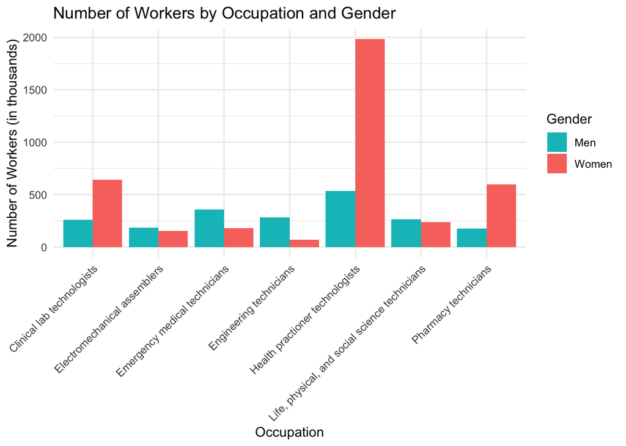

```r
lowest <- cleaned_data[cleaned_data$M.Median.weekly.earnings < 1000, ]

lowest_num_workers <- lowest |>
  group_by(Occupation) |>
  summarise(
    W.total.workers = sum(W.Num.Workers),
    M.total.workers = sum(M.Num.Workers),
    total.num.workers = sum(Total.Num.Workers)
  )

low_abbrev <- c('Clinical lab technologists', 'Electromechanical assemblers', 'Emergency medical technicians', 'Engineering technicians', 'Health practioner technologists', 'Life, physical, and social science technicians', 'Pharmacy technicians')
lowest_num_workers$Occupation <- factor(lowest_num_workers$Occupation, labels = low_abbrev)

lowest_combined <- pivot_longer(
  lowest_num_workers,
  cols = c('W.total.workers', 'M.total.workers'),
  names_to = 'Gender',
  values_to = 'Num.Workers'
  )


ggplot(lowest_combined, aes(x = Occupation, y = Num.Workers, fill = Gender)) +
  geom_bar(stat = 'identity', position = 'dodge') +
  theme_minimal() +
  theme(axis.text.x = element_text(angle = 45, hjust = 1)) +
  labs(
    title = "Number of Workers by Occupation and Gender",
    y = "Number of Workers (in thousands)"
  ) +
  scale_fill_discrete(
    labels = c('Men', 'Women'),
    type = c('#00BFC4', '#F8766D')
    )
```